# Fragmented Fandom

Visualizing MLB Media Markets, TV Rights, Viewership, and Streaming Fragmentation - *Following the money, then following the fan.* | DATS 2102 Final Project

Author

Jonah DiGiacomo

Published

May 13, 2026

# Fragmented Fandom

Baseball has always been a business, but the business has never been harder to navigate as a fan. This project follows one central question: **as MLB finds more ways to monetize its games, how complicated and expensive does it become for fans to actually watch?**

The story moves through five layers. First, the money: where national rights dollars flow and which partners now hold them. Second, the inventory: how many games land on each platform and what type of access each requires. Third, the fan budget: what it actually costs to assemble a full-season viewing stack. Fourth, the geography: how distance-based market logic compares to the real blackout restrictions MLB enforces. Fifth, a simple watchability model that synthesizes cost, platform count, and blackout risk into a single score per fan type.

All data was collected manually from public sources (MLB.com, team RSN disclosures, streaming platform pricing pages, and reported rights deal values). The fallback datasets embedded in this notebook reflect conditions as of the 2026 season.

## 1. Project Setup and Data Imports

The setup cell installs any missing packages, imports libraries, and defines shared constants and helper functions used throughout the notebook. The data-loading cell attempts to read CSVs from the project’s `data/manual` folder; if those files are not present, it falls back to the datasets built directly into the code. Roku is removed from all outputs because its MLB deal was short-term and has since lapsed.

```
Environment ready.
```

```
Datasets loaded successfully from: /Users/jonahdigiacomo/DATS_2102/FINAL PROJECT/mlb_media_project/data/manual
Media-rights rows after Roku removal: 8
Game inventory rows: 11 | Platform cost rows: 6 | Fan tier rows: 6
```

## 2. Where Is the Money Going?

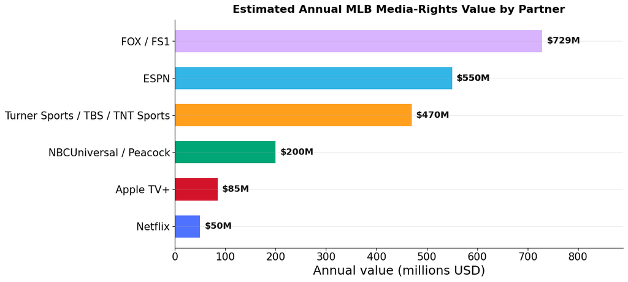

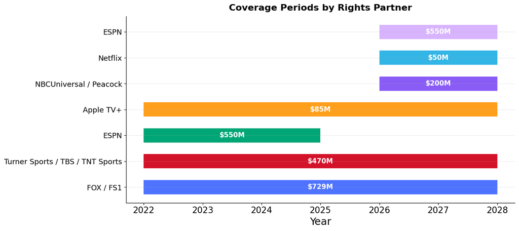

## 3. Where Are the Games Going?

Rights value tells us where the money flows. Game inventory tells us where the broadcast hours actually land. The chart below counts national games or events assigned to each package for the 2026 season.

One critical number is excluded from the chart: **MLB.TV carries approximately 2,430 out-of-market games per season** through its direct-to-consumer platform. That figure dwarfs every national package, but MLB.TV is a separate product subject to local blackout rules, so it is treated on its own in later sections.

The second chart reframes the same data by access type, answering the fan-level question: *what kind of subscription do I actually need to watch these games?*

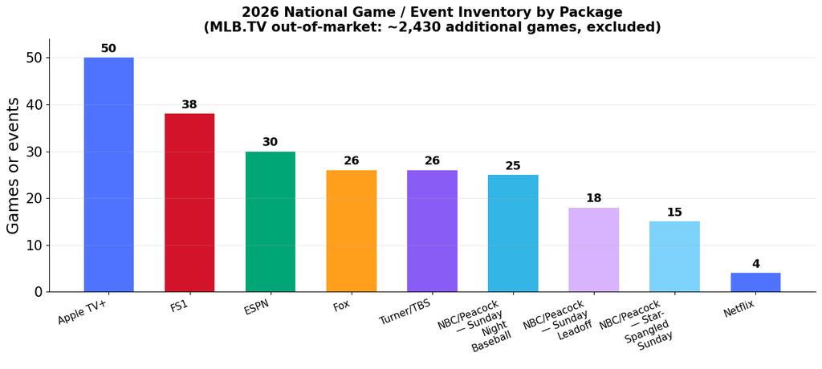

[figure not shown]

## 4. What Can Fans Actually Watch?

This section translates the platform landscape into a fan budget. The question is not whether games exist on some service, but how many subscriptions a real fan needs to assemble, and what that stack costs per season.

**Fan tier definitions used throughout this project:**

| Tier | Description |
| --- | --- |
| Casual fan | Free over-the-air broadcasts only (no paid subscription) |
| Basic cable fan | One cable or live-TV bundle; relies on RSN for local games |
| Streaming-only fan | Cord-cutter stack: Apple TV+, Peacock, Netflix |
| Out-of-market fan | MLB.TV subscriber following a team outside their home region |
| Avid national fan | Cable bundle plus streaming add-ons for broader national coverage |
| Completionist fan | Every available service: cable + MLB.TV + Apple TV+ + Peacock + Netflix. Maximum access, maximum cost. |

The scatter plot below adds a second dimension: dot size shows the number of services required, making the complexity cost visible alongside the dollar cost.

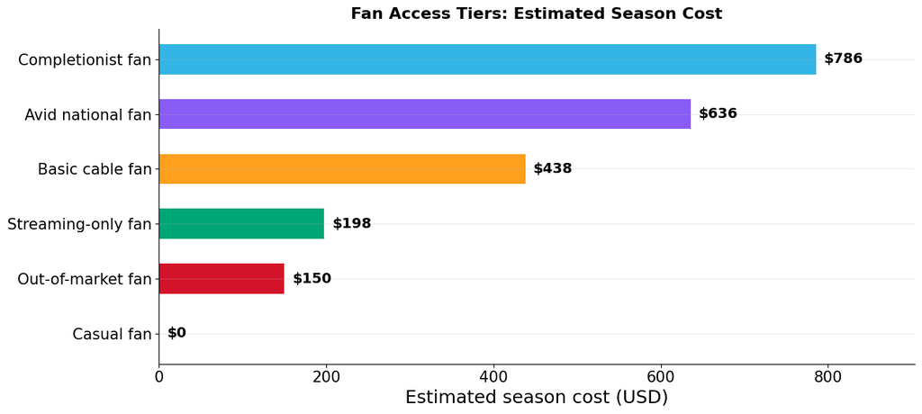

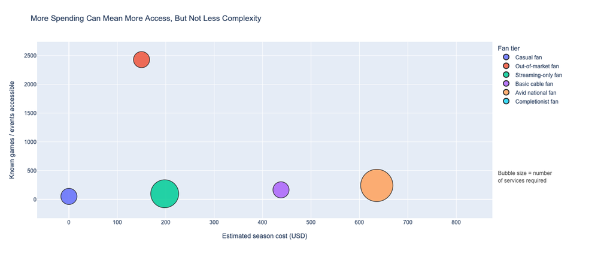

## 5. Following the Fan Over Time

Prices do not stay still. This section extends the fan-cost view back to **2022**, the year Apple TV+ launched exclusive Friday Night Baseball, marking the first time a major streaming service held MLB rights with no cable or antenna path.

Three key inflection points shaped costs over this window. Apple TV+ launched at $4.99/month in April 2022 and rose to $17.99/month by early 2024. Peacock added select MLB games starting in 2023, requiring another subscription. And ESPN’s opt-out at the end of 2025 reshuffled national packages upward for the 2026 season.

The cheapest path (free OTA antenna) never changes. Every other path rises. The completionist fan’s annual bill grew by roughly **$200** between 2022 and 2026 without any increase in the number of games watched.

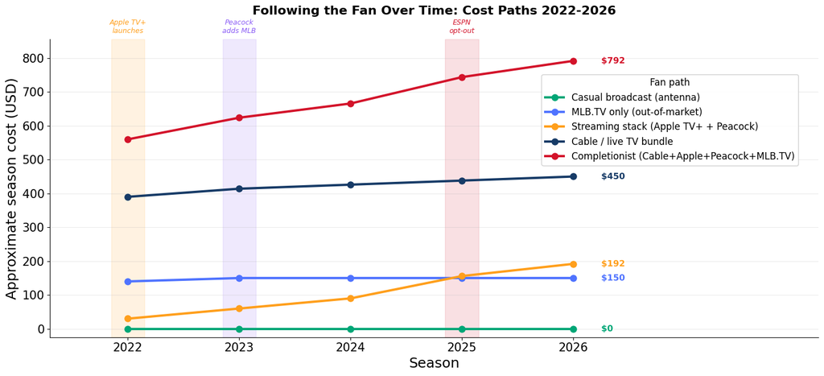

## 6. How Do Markets Matter?

The geography of MLB fandom involves two competing logics that rarely agree. The first is **distance**: a fan nearest to a stadium belongs naturally to that market. The second is **contract history**: MLB blackout rules derive from RSN agreements signed decades ago, long before streaming geography existed.

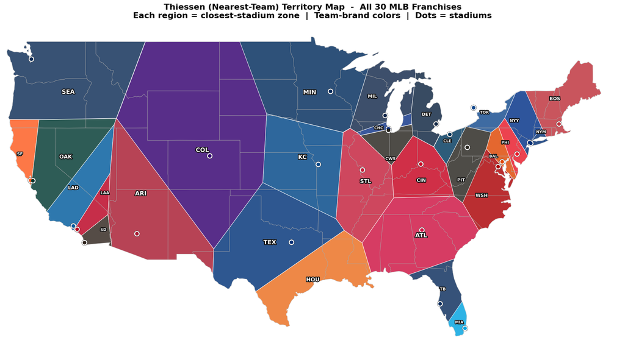

**Interactive map: Population vs. Market Geography**  
The YlOrRd choropleth shows state population (darker = more people). Dashed white lines show each team's Thiessen (nearest-stadium) territory. Notice how the largest western territories span some of the least-populated states, yet their blackout zones reach just as far as any eastern market.

Make this Notebook Trusted to load map: File -> Trust Notebook

[interactive chart not shown]

## 7. Can We Model Watchability?

The preceding sections each capture one dimension of the fan experience: cost, platform count, or blackout risk. This section combines all three into a single **Watchability Index** that summarizes how easy or difficult it is for each fan type to watch a full MLB season.

The index is constructed as a weighted composite. Blackout risk carries the most weight (45%) because it represents access uncertainty rather than just dollar cost. A fan can budget for a higher bill, but they cannot choose to be unblocked. Estimated cost carries 30% and platform count (complexity) carries 25%.

Higher scores mean easier access. The bar chart ranks fan types by their index score. The scatter plot shows the counterintuitive relationship between spending and watchability: paying more does not guarantee watching more.

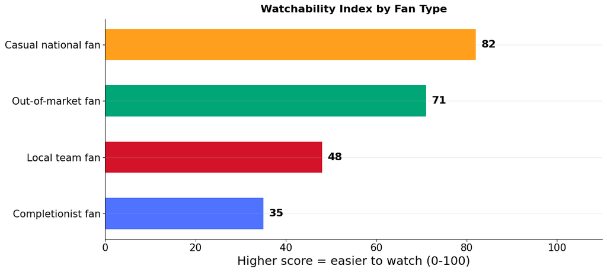

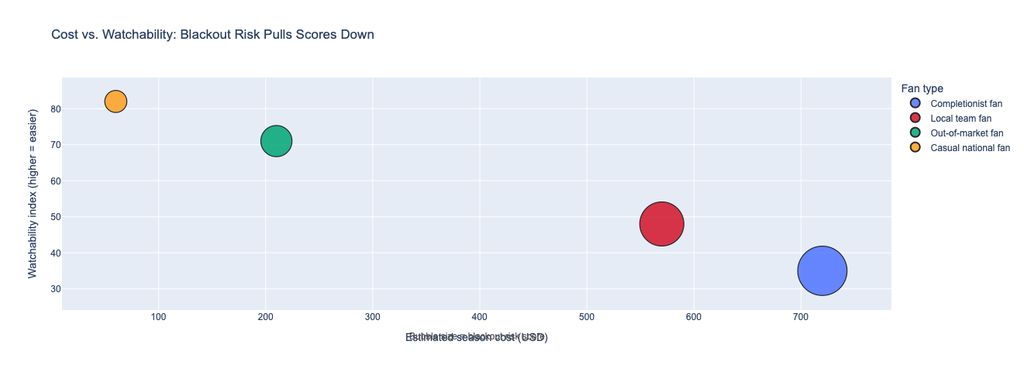

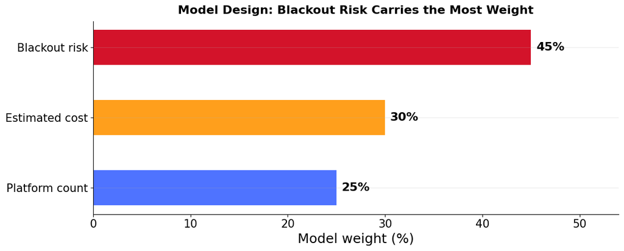

## 8. Conclusion

MLB’s media landscape shows a clear tradeoff. More platforms create more revenue for the league, but they make the fan experience harder to navigate. A fan may need broadcast TV, a cable or live-TV bundle, standalone streaming subscriptions, and MLB.TV, while still facing blackout restrictions that can block games even after paying for a service.

The project’s central finding is that **monetization and access do not move in the same direction.** As MLB games spread across more rights partners, fans face higher complexity, higher potential cost, and less certainty about where their games can be watched.

### Fan Recommendations

[output not shown]

### Recommendation to MLB

**Step 1 - Transparency:** Build a publicly searchable, ZIP-code-level blackout tool so fans can see exactly which games are blacked out for their address before paying for any subscription. Currently, fans have no reliable way to know their blackout exposure until after they have already subscribed.

**Step 2 - Reform:** Cap multi-team blackout zones to a 75-mile radius from each stadium. Fans in the Mountain West and Great Plains can live 400+ miles from any MLB city and still be blacked out by multiple franchises due to overlapping historical RSN contracts. Narrowing these zones would close the gap between what fans pay and what they can actually watch, without dismantling the underlying rights structure.

[figure not shown]